# Class Survey Analysis

Kelly Bodwin

## 0. Loading packages

**R** relies heavily on “packages” that allow users to add extra abilities to the basic functionality. For now, I will always load the required packages for you.

```r
# load packages
source("stat331_shared/Scripts/packageLoaders.R")
```

## 1. Loading and summarizing data

Our first step in any data anlysis is, of course, to get the dataset! The code below will pull the current set of responses to the in-class survey. It will then show you some information about this data. See if you can figure out what you are being shown.

```r
# Read data from current version of google spreadsheet responses
survey_orig <- gsheet2tbl("https://docs.google.com/spreadsheets/d/1CehXk2VLh9KxCdPjbDT1Aq35ZEnPxjUNnPKVLkiaxZ8/edit?usp=sharing")

# Check to make sure data is read correctly
head(survey_orig)
```

```
## # A tibble: 6 x 14
##   Times… `Whi… `Wha… `Wha… `How… `How… `Hav… `Hav… `Wha… `A h… `Whi… `Wha…
##   <chr>  <chr> <chr> <chr> <int> <chr> <chr> <chr> <chr> <chr> <chr> <chr>
## 1 1/7/2… Juni… Other Stat…     3 1     Nope! Nope  Demo… Neit… I do… Chal…
## 2 1/7/2… Seni… Comp… No m…     1 10+   Nope! Yes,… Demo… Neit… Kanye <NA>
## 3 1/7/2… Soph… Comp… No m…     2 3     Nope! I ha… Demo… Sand… I do… <NA>
## 4 1/7/2… Soph… Econ… Stat…     4 0     Yes,… Nope  Demo… Neit… Kour… Even…
## 5 1/7/2… Juni… Comp… Data…     3 7     Nope! Yes,… Demo… Sand… Kend… Fast
## 6 1/7/2… Soph… Busi… Stat…     3 1     Nope! Nope  Inde… Taco  I do… Alri…
## # ... with 2 more variables: `What are you most excited for in this
## #   class?` <chr>, `What are you most nervous about for this class?` <chr>
```

```r
summary(survey_orig)
```

```
##   Timestamp         Which best describes your school year?
##  Length:33          Length:33
##  Class :character   Class :character
##  Mode  :character   Mode  :character
##
##
##
##  What is your major or department? What is your minor?
##  Length:33                         Length:33
##  Class :character                  Class :character
##  Mode  :character                  Mode  :character
##
##
##
##  How many statistics classes have you taken, at Cal Poly or elsewhere?   (DATA course at Cal Poly count as statistics)
##  Min.   :1.000
##  1st Qu.:2.000
##  Median :3.000
##  Mean   :2.758
##  3rd Qu.:3.000
##  Max.   :5.000
##  How many computer science classes have you taken, at Cal Poly or elsewhere?
##  Length:33
##  Class :character
##  Mode  :character
##
##
##
##  Have you used R before? Have you used GitHub before?
##  Length:33               Length:33
##  Class :character        Class :character
##  Mode  :character        Mode  :character
##
##
##
##  What is your political party? A hot dog is a...
##  Length:33                     Length:33
##  Class :character              Class :character
##  Mode  :character              Mode  :character
##
```

[output cut: 15 more lines]

```
##
##  What are you most excited for in this class?
##  Length:33
##  Class :character
##  Mode  :character
##
##
##
##  What are you most nervous about for this class?
##  Length:33
##  Class :character
##  Mode  :character
##
##
##
```

```r
# Look at number of rows in dataset
nrow(survey_orig)
```

```
## [1] 33
```

## 2. Data Cleaning and Variable Editing

Often, datasets will need to be edited before we can nicely explore the information we are interested in. The code below takes the original dataset that you looked at above, and creates two new ones in its place. See if you can find the differences.

```r
# Rename variables
names(survey_orig) <- c("Timestamp", "Year", "Major", "Minor", "Stat.Classes", "CS.Classes", "R.Experience", "Git.Experience", "Political", "Hot.Dog", "Kardashian", "Cal.Poly.Word", "Excited", "Nervous")

# Keep essay responses in separate dataset, for convenience
free_response <- survey_orig %>% select(Cal.Poly.Word, Excited, Nervous)


# Drop free response and fix up factor variables
survey <- survey_orig %>%
  mutate(
    R.Class = grepl("class", R.Experience),
    R.Job = grepl("job", R.Experience),
    R.Research = grepl("research", R.Experience),
    Minor = gsub(" minor", "", Minor)
  ) %>%
  select(-Cal.Poly.Word, -Excited, -Nervous, -R.Experience) %>%
  mutate_if(is.character, factor)


# Check that this worked
head(free_response)
```

```
## # A tibble: 6 x 3
##   Cal.Poly.Word Excited                            Nervous
##   <chr>         <chr>                              <chr>
## 1 Challenging   Learning something new that I can… Not being familiar wit…
## 2 <NA>          <NA>                               <NA>
## 3 <NA>          programming with R                 Difficulty
## 4 Eventful      Becoming better at r               Learning a new code
## 5 Fast          Statistical computing              Unknown
## 6 Alright       Learning R                         That learning R will b…
```

```r
head(survey)
```

```
## # A tibble: 6 x 13
##   Times… Year  Major Minor Stat… CS.C… Git.… Poli… Hot.… Kard… R.Cl… R.Job
##   <fctr> <fct> <fct> <fct> <int> <fct> <fct> <fct> <fct> <fct> <lgl> <lgl>
## 1 1/7/2… Juni… Other Stat…     3 1     Nope  Demo… Neit… I do… F     F
## 2 1/7/2… Seni… Comp… No        1 10+   Yes,… Demo… Neit… Kanye F     F
## 3 1/7/2… Soph… Comp… No        2 3     I ha… Demo… Sand… I do… F     F
## 4 1/7/2… Soph… Econ… Stat…     4 0     Nope  Demo… Neit… Kour… T     F
## 5 1/7/2… Juni… Comp… Data…     3 7     Yes,… Demo… Sand… Kend… F     F
## 6 1/7/2… Soph… Busi… Stat…     3 1     Nope  Inde… Taco  I do… F     F
## # ... with 1 more variable: R.Research <lgl>
```

## 3. Basic Plotting

A good first step in any data exploration is to visualize the data and see what is going on. The code below will show some of the information from our class survey.

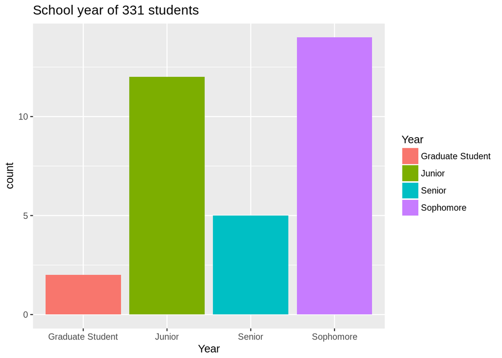

```r
# Barplots to summarize categorical variables

survey %>%
  ggplot(aes(x = Year, fill = Year)) + geom_bar() +
  ggtitle("School year of 331 students")
```

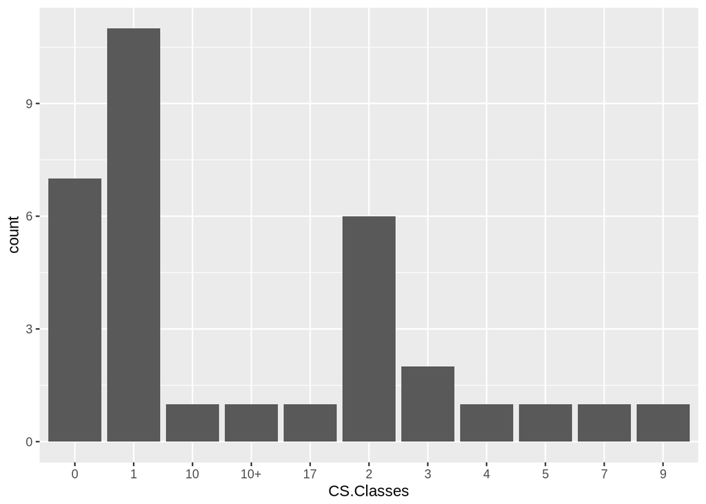

```r
# Histograms to summarize numeric variables

survey %>%
  ggplot(aes(x = CS.Classes)) + geom_histogram(stat = "count")
```

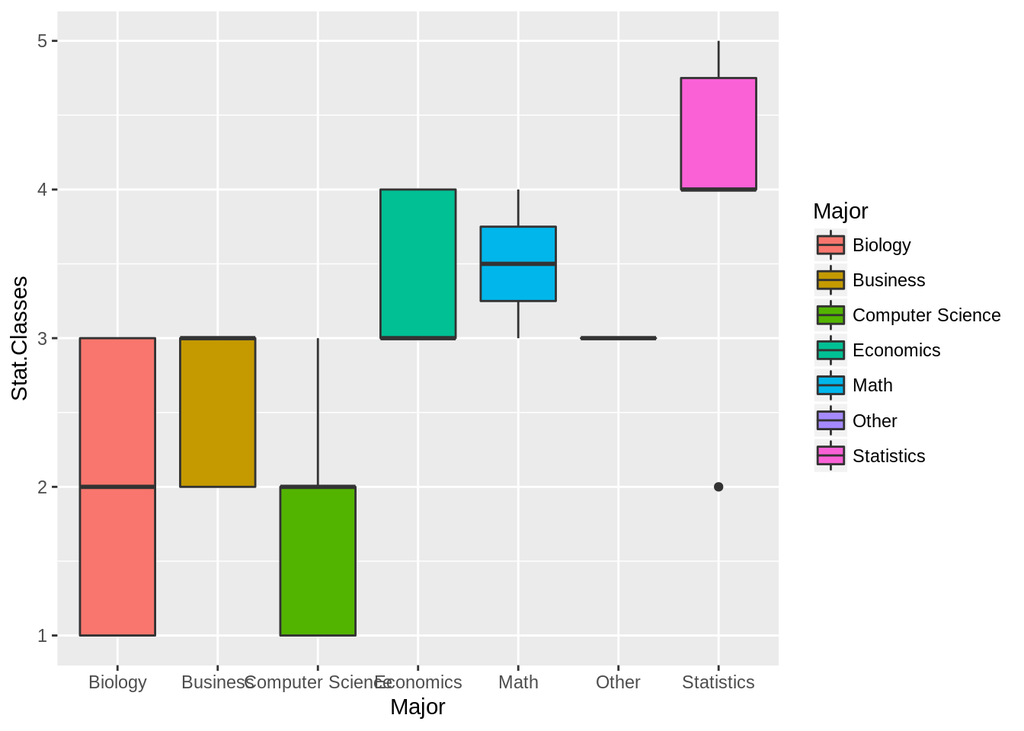

```r
# Boxplots to compare a numeric variable and categorical variable

survey %>%
  ggplot(aes(y = Stat.Classes, x = Major, fill = Major)) + geom_boxplot()
```

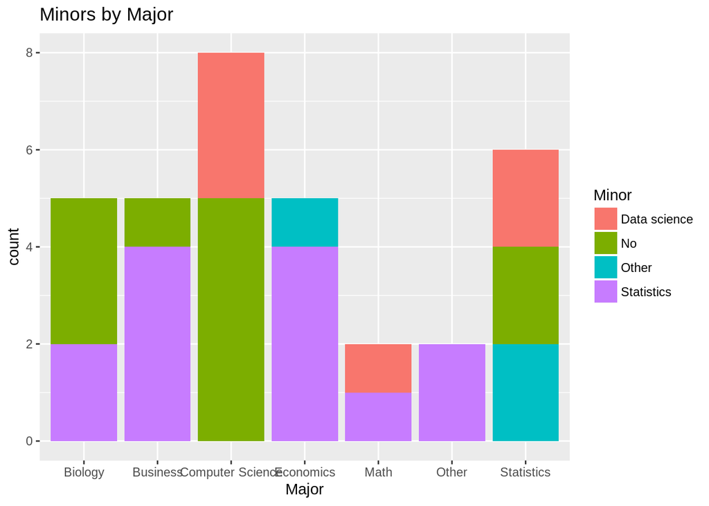

```r
# Barplots to compare two or more categorical variables

survey %>%
  ggplot(aes(x = Major, fill = Minor)) + geom_bar() +
  ggtitle("Minors by Major")
```

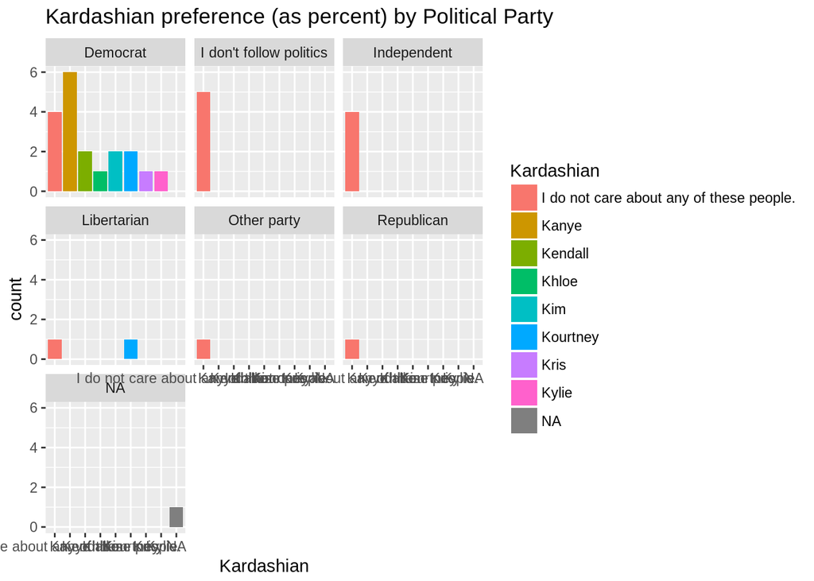

```r
survey %>%
  ggplot(aes(x = Kardashian, fill = Kardashian)) + facet_wrap(~Political) + geom_bar(postion = "fill") +
  ggtitle("Kardashian preference (as percent) by Political Party")
```

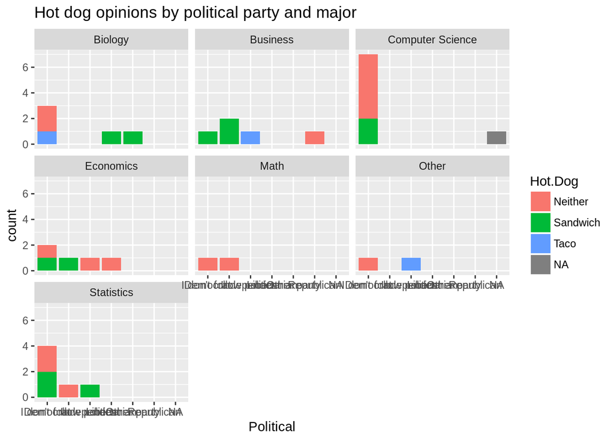

```r
survey %>%
  ggplot(aes(x = Political, fill = Hot.Dog)) + facet_wrap(~Major) + geom_bar() +
  ggtitle("Hot dog opinions by political party and major")
```

## 4. Reshaping data

Often, datasets contain all the information we need, but not in a format that is easy to analyze. A subtle skill, which we will study later, is “reshaping” datasets to more easily answer questions.

Use your console to look at `survey_courses_1` and `survey_courses_2`. (It is okay if you need to ask for help with this step.)

```r
# Create "wide" dataset with coursework

survey_courses_1 <- survey %>%
  select(Major, Minor, Year, Stat.Classes, CS.Classes)

survey_courses_2 <- survey %>%
  gather(Stat.Classes, CS.Classes, key = Subject, value = Num.Classes) %>%
  mutate(
    Subject = gsub(".Classes", "", Subject)
  )
```

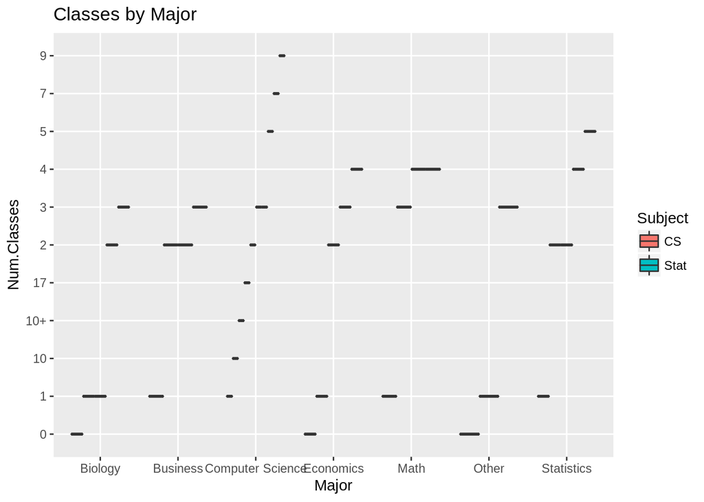

```r
# Compare coursework by major

survey_courses_2 %>%
  ggplot(aes(x = Major, y = Num.Classes, fill = Subject)) + geom_boxplot() +
  ggtitle("Classes by Major")
```

## 5. Words and strings

In the second half of this course, we will learn to leverage our skills in modern and exciting contexts, especially those with nontraditional data. Check out the output below to see what your classmates have to say about Cal Poly and this course!

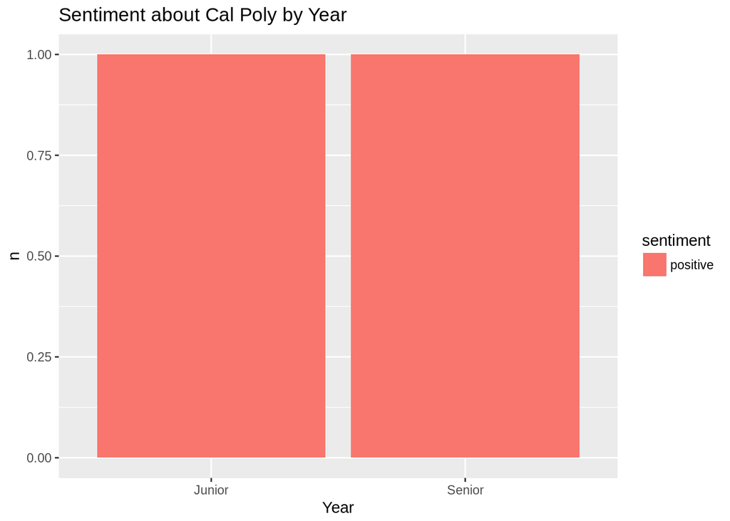

```r
cal_poly_sentiment <- survey_orig %>%
  select(Cal.Poly.Word, Year) %>%
  inner_join(get_sentiments("bing"), by = c("Cal.Poly.Word" = "word"))



cal_poly_sentiment %>%
  count(Year, sentiment) %>%
  ggplot(aes(x = Year, y = n, fill = sentiment)) + geom_col(position = "fill") +
  ggtitle("Sentiment about Cal Poly by Year")
```

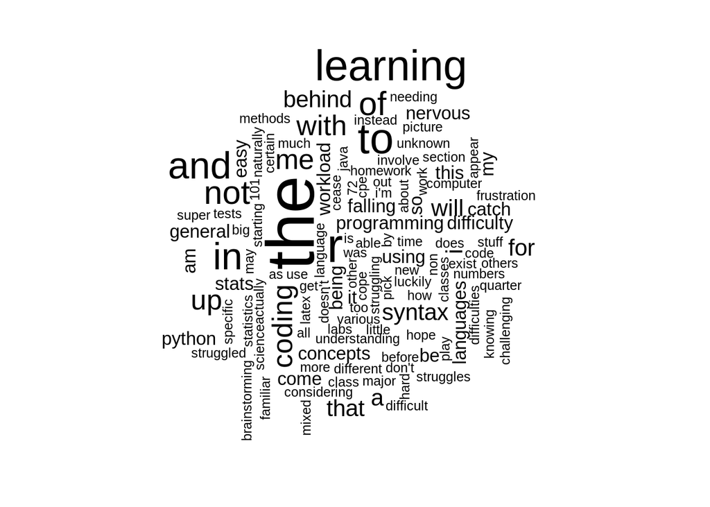

```r
nervous_words <- free_response %>%
  unnest_tokens(word, Nervous) %>%
  count(word)



with(nervous_words,
  wordcloud(words = word, freq = n, min.freq = 1, rot.per = 0.35)
)
```

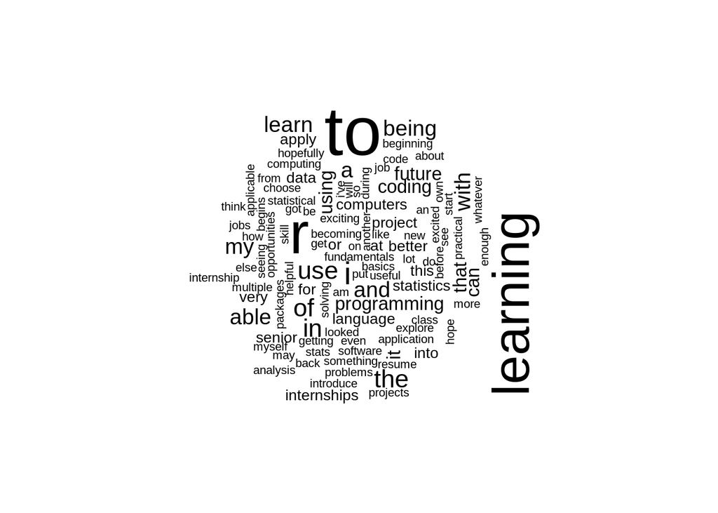

```r
excited_words <- free_response %>%
  unnest_tokens(word, Excited) %>%
  count(word)



with(excited_words,
  wordcloud(words = word, freq = n, min.freq = 1, rot.per = 0.3)
)
```